GET  
FILE='Z:\Documents\GitHub\STISIM-Task-Analysis\SPSS Results\Saccade_peakV_5-15.sav'.  
DATASET NAME DataSet1 WINDOW=FRONT.  
* Encoding: UTF-8.  
EXAMINE VARIABLES=S1_R1 S1_R2 S2_R1 S2_R2  
/PLOT BOXPLOT NPPLOT  
/COMPARE GROUPS  
/STATISTICS NONE  
/CINTERVAL 95  
/MISSING LISTWISE  
/NOTOTAL.

# **Explore**

NotesNotes, table, 0 levels of column headers and 2 levels of row headers, table with 3 columns and 14 rows

| Output Created |  | 16-APR-2019 00:43:56 |
| --- | --- | --- |
| Comments |  |  |
| Input | Data | Z:\Documents\GitHub\STISIM-Task-Analysis\SPSS Results\Saccade_peakV_5-15.sav |
|  | Active Dataset | DataSet1 |
|  | Filter | <none> |
|  | Weight | <none> |
|  | Split File | <none> |
|  | N of Rows in Working Data File | 13 |
| Missing Value Handling | Definition of Missing | User-defined missing values for dependent variables are treated as missing. |
|  | Cases Used | Statistics are based on cases with no missing values for any dependent variable or factor used. |
| Syntax |  | EXAMINE VARIABLES=S1_R1 S1_R2 S2_R1 S2_R2 /PLOT BOXPLOT NPPLOT /COMPARE GROUPS /STATISTICS NONE /CINTERVAL 95 /MISSING LISTWISE /NOTOTAL. |
| Resources | Processor Time | 00:00:08.36 |
|  | Elapsed Time | 00:00:07.26 |

[DataSet1] Z:\Documents\GitHub\STISIM-Task-Analysis\SPSS Results\Saccade_peakV_5-15.sav

Case Processing SummaryCase Processing Summary, table, 3 levels of column headers and 1 levels of row headers, table with 7 columns and 8 rows

|  | Cases |  |  |  |  |  |
| --- | --- | --- | --- | --- | --- | --- |
|  | Valid |  | Missing |  | Total |  |
|  | N | Percent | N | Percent | N | Percent |
| S1_R1 | 9 | 69.2% | 4 | 30.8% | 13 | 100.0% |
| S1_R2 | 9 | 69.2% | 4 | 30.8% | 13 | 100.0% |
| S2_R1 | 9 | 69.2% | 4 | 30.8% | 13 | 100.0% |
| S2_R2 | 9 | 69.2% | 4 | 30.8% | 13 | 100.0% |

Tests of NormalityTests of Normality, table, 2 levels of column headers and 1 levels of row headers, table with 7 columns and 9 rows

|  | Kolmogorov-Smirnov<sup>a</sup> |  |  | Shapiro-Wilk |  |  |
| --- | --- | --- | --- | --- | --- | --- |
|  | Statistic | df | Sig. | Statistic | df | Sig. |
| S1_R1 | .155 | 9 | .200* | .974 | 9 | .928 |
| S1_R2 | .159 | 9 | .200* | .979 | 9 | .960 |
| S2_R1 | .191 | 9 | .200* | .915 | 9 | .353 |
| S2_R2 | .124 | 9 | .200* | .960 | 9 | .802 |

*. This is a lower bound of the true significance.  
a. Lilliefors Significance Correction

# **S1_R1**

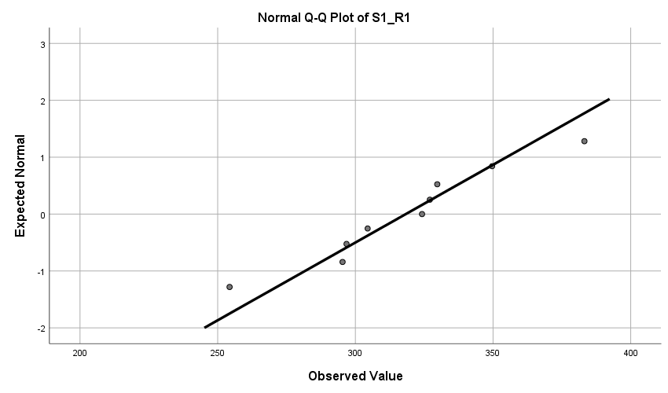

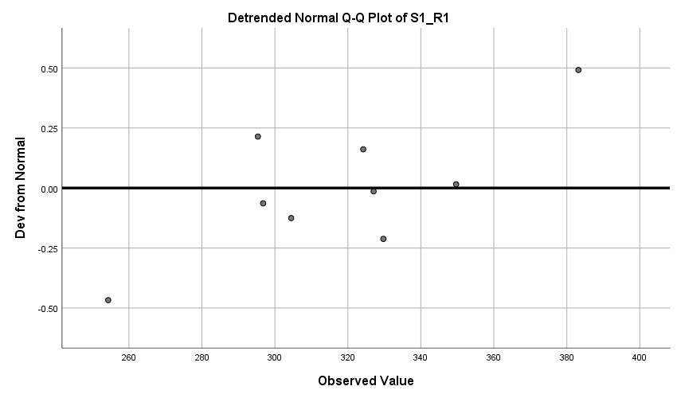

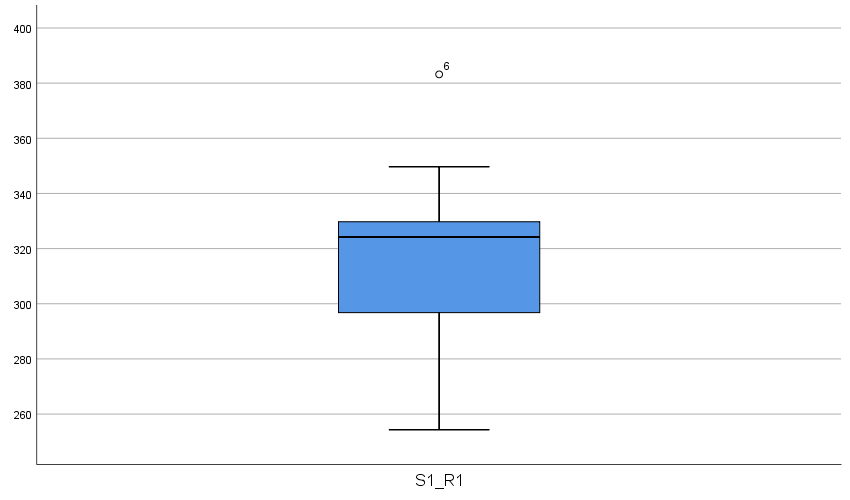

# **S1_R2**

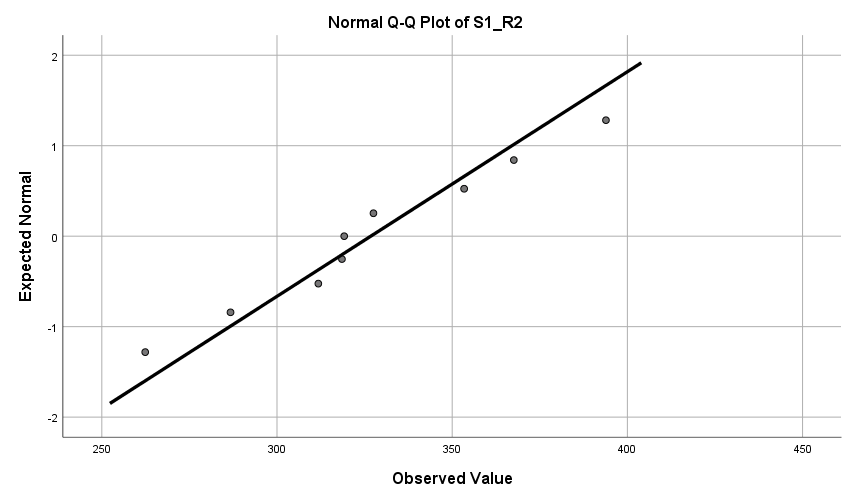

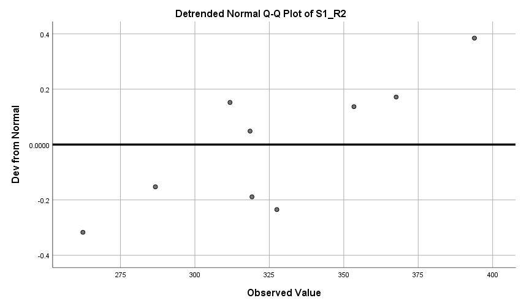

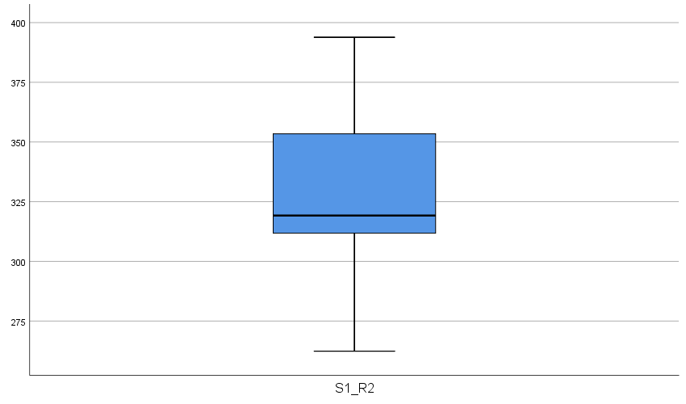

# **S2_R1**

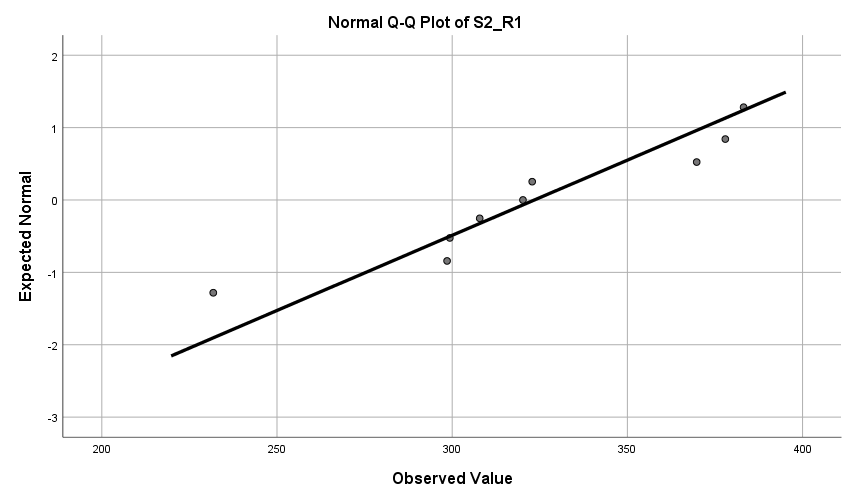

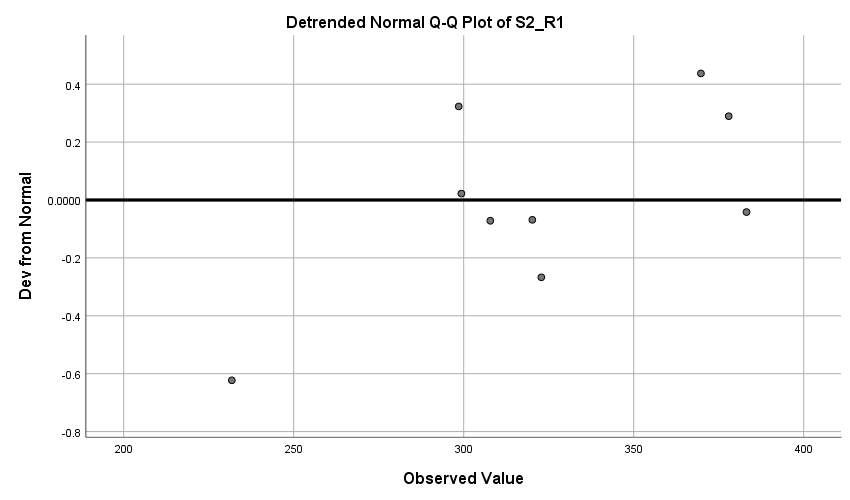

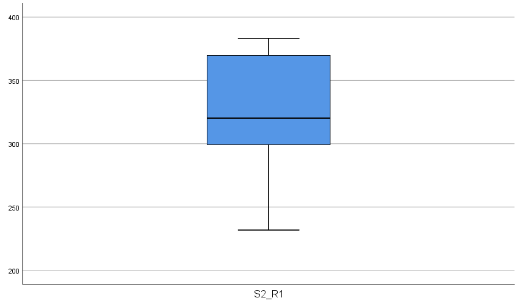

# **S2_R2**

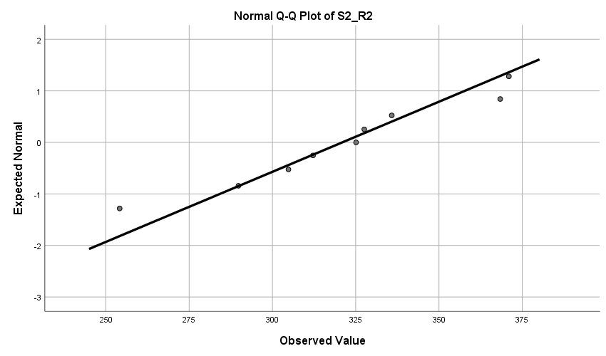

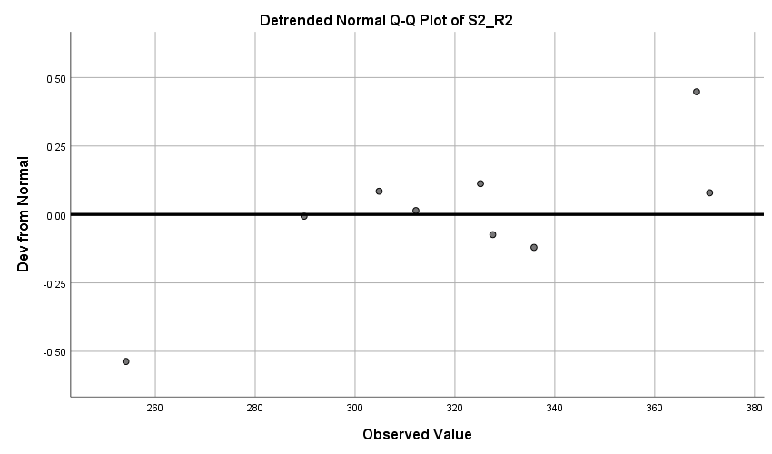

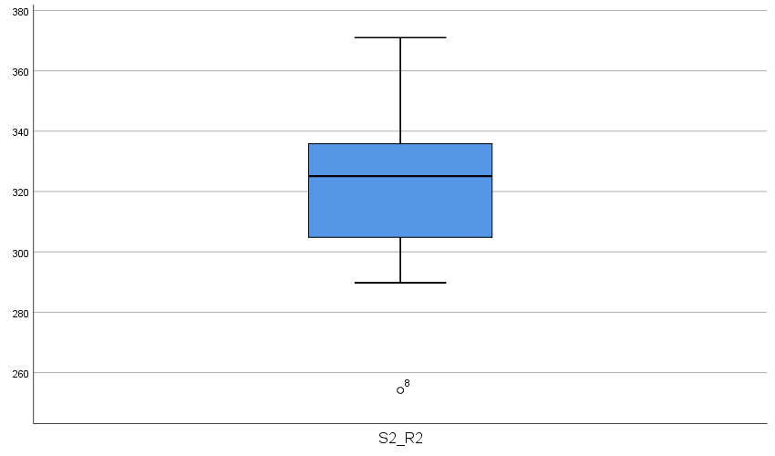

T-TEST PAIRS=S1_R1 S2_R1 S1_R2 WITH S1_R2 S2_R2 S2_R2 (PAIRED)  
/CRITERIA=CI(.9500)  
/MISSING=ANALYSIS.

# **T-Test**

NotesNotes, table, 0 levels of column headers and 2 levels of row headers, table with 3 columns and 14 rows

| Output Created |  | 16-APR-2019 00:44:03 |
| --- | --- | --- |
| Comments |  |  |
| Input | Data | Z:\Documents\GitHub\STISIM-Task-Analysis\SPSS Results\Saccade_peakV_5-15.sav |
|  | Active Dataset | DataSet1 |
|  | Filter | <none> |
|  | Weight | <none> |
|  | Split File | <none> |
|  | N of Rows in Working Data File | 13 |
| Missing Value Handling | Definition of Missing | User defined missing values are treated as missing. |
|  | Cases Used | Statistics for each analysis are based on the cases with no missing or out-of-range data for any variable in the analysis. |
| Syntax |  | T-TEST PAIRS=S1_R1 S2_R1 S1_R2 WITH S1_R2 S2_R2 S2_R2 (PAIRED) /CRITERIA=CI(.9500) /MISSING=ANALYSIS. |
| Resources | Processor Time | 00:00:00.03 |
|  | Elapsed Time | 00:00:00.04 |

Paired Samples StatisticsPaired Samples Statistics, table, 1 levels of column headers and 2 levels of row headers, table with 6 columns and 8 rows

|  |  | Mean | N | Std. Deviation | Std. Error Mean |
| --- | --- | --- | --- | --- | --- |
| Pair 1 | S1_R1 | 334.091818 | 11 | 56.2219823 | 16.9515655 |
|  | S1_R2 | 338.564545 | 11 | 46.0364496 | 13.8805118 |
| Pair 2 | S2_R1 | 323.485455 | 11 | 49.5919416 | 14.9525330 |
|  | S2_R2 | 319.701818 | 11 | 43.4841741 | 13.1109718 |
| Pair 3 | S1_R2 | 333.982727 | 11 | 58.7402937 | 17.7108649 |
|  | S2_R2 | 319.701818 | 11 | 43.4841741 | 13.1109718 |

Paired Samples CorrelationsPaired Samples Correlations, table, 1 levels of column headers and 2 levels of row headers, table with 5 columns and 5 rows

|  |  | N | Correlation | Sig. |
| --- | --- | --- | --- | --- |
| Pair 1 | S1_R1 & S1_R2 | 11 | .906 | .000 |
| Pair 2 | S2_R1 & S2_R2 | 11 | .918 | .000 |
| Pair 3 | S1_R2 & S2_R2 | 11 | .893 | .000 |

Paired Samples TestPaired Samples Test, table, 3 levels of column headers and 2 levels of row headers, table with 10 columns and 7 rows

|  |  | Paired Differences |  |  |  |  | t | df | Sig. (2-tailed) |  |  |  |
| --- | --- | --- | --- | --- | --- | --- | --- | --- | --- | --- | --- | --- |
|  |  | Mean | Std. Deviation | Std. Error Mean | 95% Confidence Interval of the Difference |  |  |  |  |  |  |  |
|  |  |  |  |  | Lower | Upper |  |  |  |  |  |  |
| Pair 1 | S1_R1 - S1_R2 | -4.4727273 | 24.3234225 | 7.3337878 | -20.8134248 | 11.8679703 |  |  |  | -.610 | 10 | .556 |
| Pair 2 | S2_R1 - S2_R2 | 3.7836364 | 19.8159089 | 5.9747213 | -9.5288724 | 17.0961451 |  |  |  | .633 | 10 | .541 |
| Pair 3 | S1_R2 - S2_R2 | 14.2809091 | 27.9492062 | 8.4270028 | -4.4956231 | 33.0574413 | 1.695 | 10 | .121 |  |  |  |

COMPUTE logS1_R1=LG10(S1_R1).  
EXECUTE.  
COMPUTE logS1_R2=LG10(S1_R2).  
EXECUTE.  
COMPUTE logS2_R1=LG10(S2_R1).  
EXECUTE.  
COMPUTE logS2_R2=LG10(S2_R2).  
EXECUTE.  
EXAMINE VARIABLES=logS1_R1 logS1_R2 logS2_R1 logS2_R2  
/PLOT NPPLOT  
/STATISTICS NONE  
/CINTERVAL 95  
/MISSING LISTWISE  
/NOTOTAL.

# **Explore**

NotesNotes, table, 0 levels of column headers and 2 levels of row headers, table with 3 columns and 14 rows

| Output Created |  | 16-APR-2019 00:44:04 |
| --- | --- | --- |
| Comments |  |  |
| Input | Data | Z:\Documents\GitHub\STISIM-Task-Analysis\SPSS Results\Saccade_peakV_5-15.sav |
|  | Active Dataset | DataSet1 |
|  | Filter | <none> |
|  | Weight | <none> |
|  | Split File | <none> |
|  | N of Rows in Working Data File | 13 |
| Missing Value Handling | Definition of Missing | User-defined missing values for dependent variables are treated as missing. |
|  | Cases Used | Statistics are based on cases with no missing values for any dependent variable or factor used. |
| Syntax |  | EXAMINE VARIABLES=logS1_R1 logS1_R2 logS2_R1 logS2_R2 /PLOT NPPLOT /STATISTICS NONE /CINTERVAL 95 /MISSING LISTWISE /NOTOTAL. |
| Resources | Processor Time | 00:00:01.56 |
|  | Elapsed Time | 00:00:01.50 |

Case Processing SummaryCase Processing Summary, table, 3 levels of column headers and 1 levels of row headers, table with 7 columns and 8 rows

|  | Cases |  |  |  |  |  |
| --- | --- | --- | --- | --- | --- | --- |
|  | Valid |  | Missing |  | Total |  |
|  | N | Percent | N | Percent | N | Percent |
| logS1_R1 | 9 | 69.2% | 4 | 30.8% | 13 | 100.0% |
| logS1_R2 | 9 | 69.2% | 4 | 30.8% | 13 | 100.0% |
| logS2_R1 | 9 | 69.2% | 4 | 30.8% | 13 | 100.0% |
| logS2_R2 | 9 | 69.2% | 4 | 30.8% | 13 | 100.0% |

Tests of NormalityTests of Normality, table, 2 levels of column headers and 1 levels of row headers, table with 7 columns and 9 rows

|  | Kolmogorov-Smirnov<sup>a</sup> |  |  | Shapiro-Wilk |  |  |
| --- | --- | --- | --- | --- | --- | --- |
|  | Statistic | df | Sig. | Statistic | df | Sig. |
| logS1_R1 | .166 | 9 | .200* | .970 | 9 | .891 |
| logS1_R2 | .151 | 9 | .200* | .979 | 9 | .958 |
| logS2_R1 | .217 | 9 | .200* | .895 | 9 | .226 |
| logS2_R2 | .127 | 9 | .200* | .950 | 9 | .694 |

*. This is a lower bound of the true significance.  
a. Lilliefors Significance Correction

# **logS1_R1**

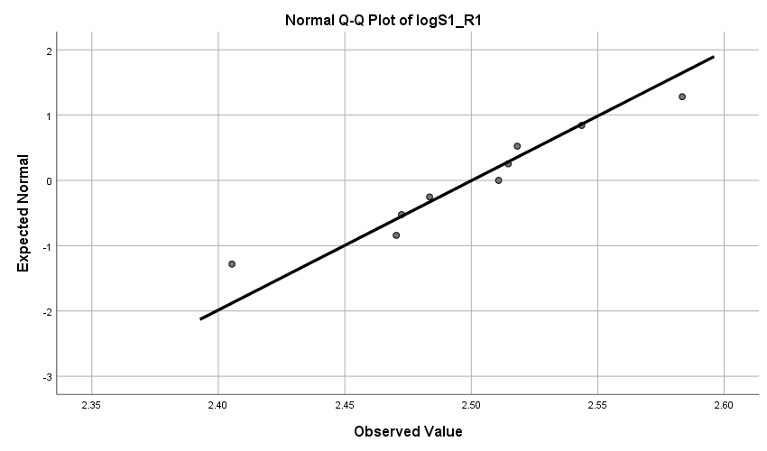

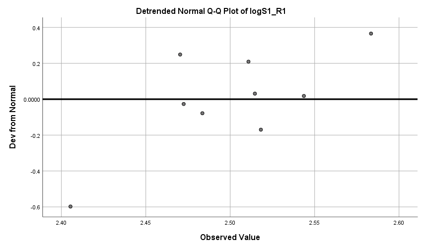

# **logS1_R2**

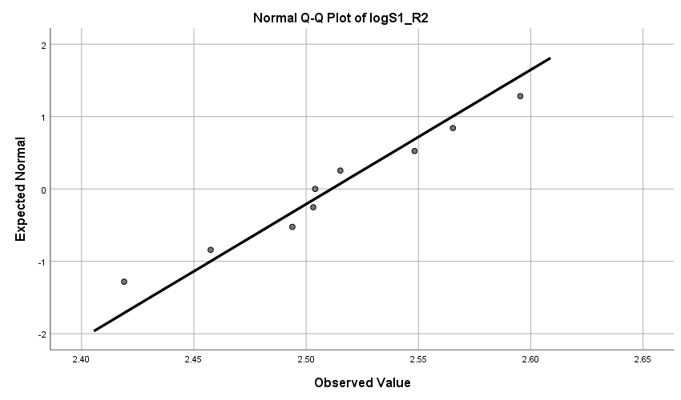

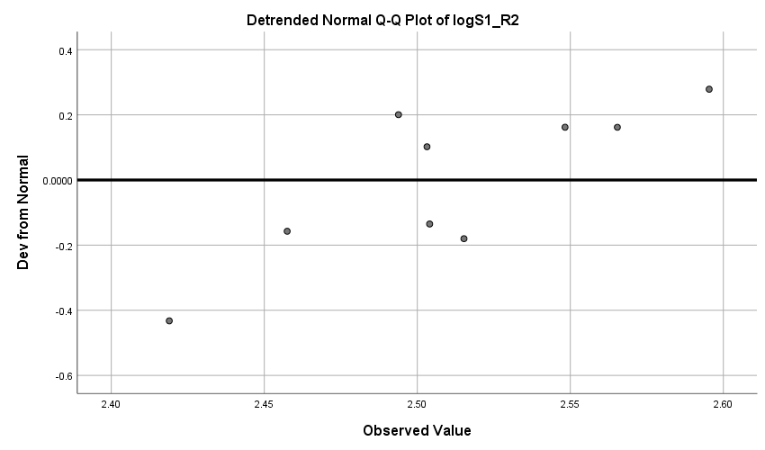

# **logS2_R1**

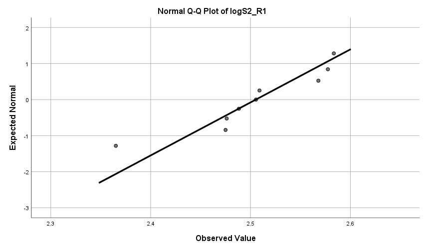

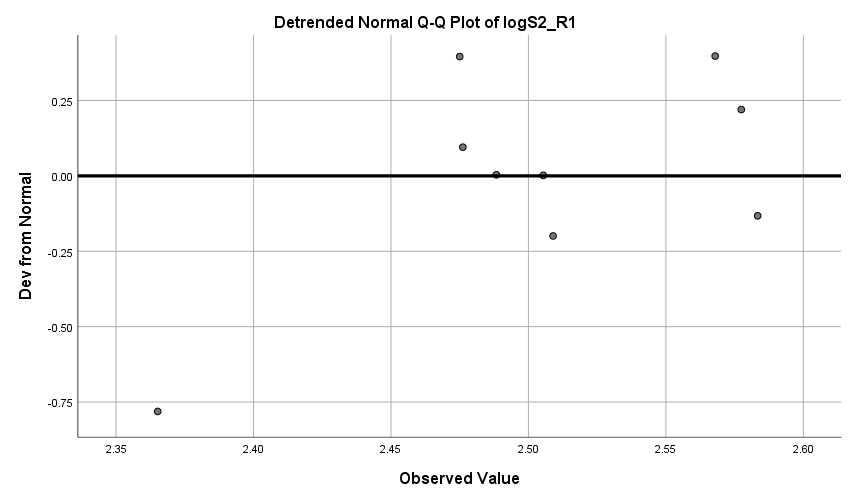

# **logS2_R2**

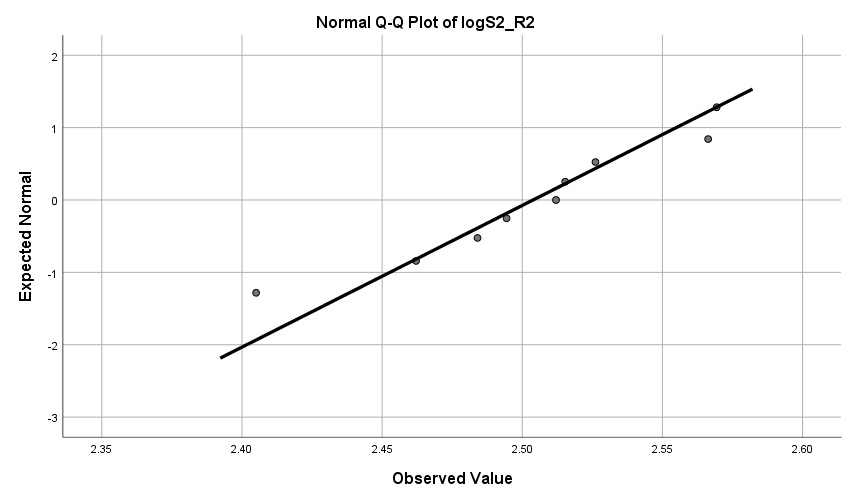

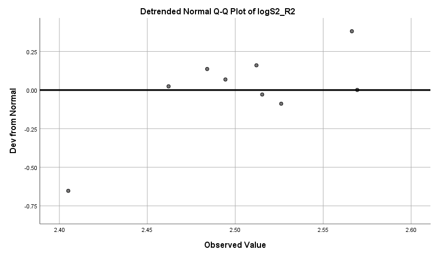

T-TEST PAIRS=logS1_R1 logS2_R1 logS1_R2 WITH logS1_R2 logS2_R2 logS2_R2 (PAIRED)  
/CRITERIA=CI(.9500)  
/MISSING=ANALYSIS.

# **T-Test**

NotesNotes, table, 0 levels of column headers and 2 levels of row headers, table with 3 columns and 14 rows

| Output Created |  | 16-APR-2019 00:44:06 |
| --- | --- | --- |
| Comments |  |  |
| Input | Data | Z:\Documents\GitHub\STISIM-Task-Analysis\SPSS Results\Saccade_peakV_5-15.sav |
|  | Active Dataset | DataSet1 |
|  | Filter | <none> |
|  | Weight | <none> |
|  | Split File | <none> |
|  | N of Rows in Working Data File | 13 |
| Missing Value Handling | Definition of Missing | User defined missing values are treated as missing. |
|  | Cases Used | Statistics for each analysis are based on the cases with no missing or out-of-range data for any variable in the analysis. |
| Syntax |  | T-TEST PAIRS=logS1_R1 logS2_R1 logS1_R2 WITH logS1_R2 logS2_R2 logS2_R2 (PAIRED) /CRITERIA=CI(.9500) /MISSING=ANALYSIS. |
| Resources | Processor Time | 00:00:00.02 |
|  | Elapsed Time | 00:00:00.00 |

Paired Samples StatisticsPaired Samples Statistics, table, 1 levels of column headers and 2 levels of row headers, table with 6 columns and 8 rows

|  |  | Mean | N | Std. Deviation | Std. Error Mean |
| --- | --- | --- | --- | --- | --- |
| Pair 1 | logS1_R1 | 2.5187 | 11 | .06877 | .02073 |
|  | logS1_R2 | 2.5260 | 11 | .05959 | .01797 |
| Pair 2 | logS2_R1 | 2.5050 | 11 | .06934 | .02091 |
|  | logS2_R2 | 2.5009 | 11 | .06088 | .01836 |
| Pair 3 | logS1_R2 | 2.5180 | 11 | .07307 | .02203 |
|  | logS2_R2 | 2.5009 | 11 | .06088 | .01836 |

Paired Samples CorrelationsPaired Samples Correlations, table, 1 levels of column headers and 2 levels of row headers, table with 5 columns and 5 rows

|  |  | N | Correlation | Sig. |
| --- | --- | --- | --- | --- |
| Pair 1 | logS1_R1 & logS1_R2 | 11 | .913 | .000 |
| Pair 2 | logS2_R1 & logS2_R2 | 11 | .916 | .000 |
| Pair 3 | logS1_R2 & logS2_R2 | 11 | .912 | .000 |

Paired Samples TestPaired Samples Test, table, 3 levels of column headers and 2 levels of row headers, table with 10 columns and 7 rows

|  |  | Paired Differences |  |  |  |  | t | df | Sig. (2-tailed) |  |  |  |
| --- | --- | --- | --- | --- | --- | --- | --- | --- | --- | --- | --- | --- |
|  |  | Mean | Std. Deviation | Std. Error Mean | 95% Confidence Interval of the Difference |  |  |  |  |  |  |  |
|  |  |  |  |  | Lower | Upper |  |  |  |  |  |  |
| Pair 1 | logS1_R1 - logS1_R2 | -.00722 | .02818 | .00850 | -.02615 | .01171 |  |  |  | -.850 | 10 | .415 |
| Pair 2 | logS2_R1 - logS2_R2 | .00402 | .02790 | .00841 | -.01473 | .02277 |  |  |  | .478 | 10 | .643 |
| Pair 3 | logS1_R2 - logS2_R2 | .01704 | .03048 | .00919 | -.00344 | .03751 | 1.854 | 10 | .093 |  |  |  |

*Nonparametric Tests: Related Samples.  
NPAR TESTS  
/WILCOXON=logS1_R1 logS2_R1 logS1_R2 WITH logS1_R2 logS2_R2 logS2_R2 (PAIRED)  
/MISSING ANALYSIS.

# **NPar Tests**

NotesNotes, table, 0 levels of column headers and 2 levels of row headers, table with 3 columns and 16 rows

| Output Created |  | 16-APR-2019 00:44:06 |
| --- | --- | --- |
| Comments |  |  |
| Input | Data | Z:\Documents\GitHub\STISIM-Task-Analysis\SPSS Results\Saccade_peakV_5-15.sav |
|  | Active Dataset | DataSet1 |
|  | Filter | <none> |
|  | Weight | <none> |
|  | Split File | <none> |
|  | N of Rows in Working Data File | 13 |
| Missing Value Handling | Definition of Missing | User-defined missing values are treated as missing. |
|  | Cases Used | Statistics for each test are based on all cases with valid data for the variable(s) used in that test. |
| Syntax |  | NPAR TESTS /WILCOXON=logS1_R1 logS2_R1 logS1_R2 WITH logS1_R2 logS2_R2 logS2_R2 (PAIRED) /MISSING ANALYSIS. |
| Resources | Processor Time | 00:00:00.00 |
|  | Elapsed Time | 00:00:00.00 |
|  | Number of Cases Allowed<sup>a</sup> | 349525 |

a. Based on availability of workspace memory.

# **Wilcoxon Signed Ranks Test**

RanksRanks, table, 1 levels of column headers and 2 levels of row headers, table with 5 columns and 23 rows

|  |  | N | Mean Rank | Sum of Ranks |
| --- | --- | --- | --- | --- |
| logS1_R2 - logS1_R1 | Negative Ranks | 4<sup>a</sup> | 5.25 | 21.00 |
|  | Positive Ranks | 7<sup>b</sup> | 6.43 | 45.00 |
|  | Ties | 0<sup>c</sup> |  |  |
|  | Total | 11 |  |  |
| logS2_R2 - logS2_R1 | Negative Ranks | 7<sup>d</sup> | 5.57 | 39.00 |
|  | Positive Ranks | 4<sup>e</sup> | 6.75 | 27.00 |
|  | Ties | 0<sup>f</sup> |  |  |
|  | Total | 11 |  |  |
| logS2_R2 - logS1_R2 | Negative Ranks | 7<sup>g</sup> | 7.57 | 53.00 |
|  | Positive Ranks | 4<sup>h</sup> | 3.25 | 13.00 |
|  | Ties | 0<sup>i</sup> |  |  |
|  | Total | 11 |  |  |

a. logS1_R2 < logS1_R1  
b. logS1_R2 > logS1_R1  
c. logS1_R2 = logS1_R1  
d. logS2_R2 < logS2_R1  
e. logS2_R2 > logS2_R1  
f. logS2_R2 = logS2_R1  
g. logS2_R2 < logS1_R2  
h. logS2_R2 > logS1_R2  
i. logS2_R2 = logS1_R2

Test Statistics<sup>a</sup>Test Statistics, table, 1 levels of column headers and 1 levels of row headers, table with 4 columns and 7 rows

|  | logS1_R2 - logS1_R1 | logS2_R2 - logS2_R1 | logS2_R2 - logS1_R2 |
| --- | --- | --- | --- |
| Z | -1.067<sup>b</sup> | -.533<sup>c</sup> | -1.778<sup>c</sup> |
| Asymp. Sig. (2-tailed) | .286 | .594 | .075 |

a. Wilcoxon Signed Ranks Test  
b. Based on negative ranks.  
c. Based on positive ranks.